# DUI Incident Rates in Boston from 2019, 2021-2023

Asma Syed

2023-12-17

## Introduction

This project analyzes DUI (drunk driving incidents) in Boston to identify patterns related to holidays, weekends, and seasonal trends. National statistics suggest higher risk during these times. For example, Driver’s Ed reports that 25% of adults consume more alcohol during the holiday season, and Injury Facts identifies Saturday as the most dangerous day to drive.

The data set is sourced from from the Boston Police Department Database: https://data.boston.gov/dataset/crime-incident-reports-august-2015-to-date-source-new-system The analysis focuses on DUI incidents from the years 2019, 2021, 2022, and 2023.

## Data Cleaning and Preperation

After loading the data into R, there were four separate data sets with 17 variables each. The 2019 dataset had 87,184 incidents, the 2021 data had 71,721 incidents, the 2022 data had 73,852, and lastly the 2023 data had 74,040 incidents. The year 2023 data set is incomplete, with the most recent incident recorded on December 12, 2023.

The data sets were combined into a single data set totaling 306,797 observations. To focus the analysis on DUI related incidents, all other crime types were filtered out.

The resulting data set consists 373 reported DUI incidents and the following variables:

| Variable | Description |
| --- | --- |
| OFFENSE_CODE | Code assigned to each type of crime |
| OFFENSE_DESCRIPTION | Description of the crime |
| OCCURRED_ON_DATE | Date and time when the crime occurred |
| YEAR | Year in which the crime occurred |
| MONTH | Month in which the crime occurred |

To analyze trends related to holidays, weekends, and warmer months, additional columns were created to classify each observation accordingly. The following holidays were considered:

1. New Year’s Day
2. Super Bowl Sunday
3. President’s Day
4. St. Patrick’s Day
5. Memorial Day
6. Juneteenth
7. Fourth of July
8. Labor Day
9. Halloween
10. Thanksgiving
11. Christmas Eve
12. Christmas Day
13. New Year’s Eve

Observations from May through September were classified as occurring in warmer months. These classifications were implemented in R using the `mutate()` function along with the `case_when()` function.

## Statistical Analysis and Model Building

Given that the data set contains a single response variable, a linear model was not suitable for analysis. Instead, summray statistics were computed to explore trends in DUI incidents.

Further analysis grouped incidents by:

1. Year and weekends: 0=weekdays, 1= weekends
   - Approximately 40% of DUI incidents occurred on weekends, while 60% occurred on weekdays.
2. Year and warmer months: 0= colder months (October-April), 1= warmer months (May-September)
   - About 40% of incidents occurred during the warmer months, with the remaining 60% in colder months.

For weekends, more accidents occurred during the weekdays- about 40% of DUI incidents occurred during the weekend and 60% during the weekdays.  
For warmer months, about 40% of DUI incidents occurred between May and September while 60% occurred during the colder months.

Bar plots were generated to visualize trends in each variable of interest by year, showing patterns in DUI incidents across holidays, weekends, and warmer months.

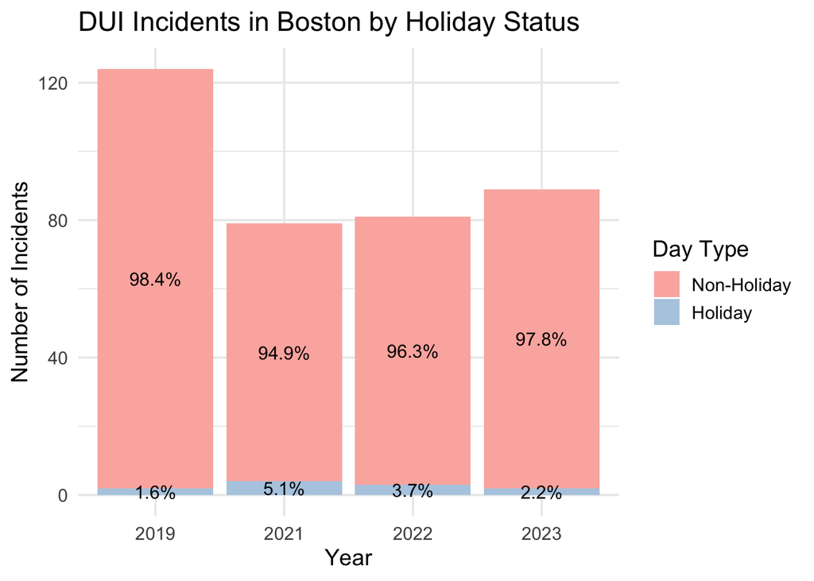

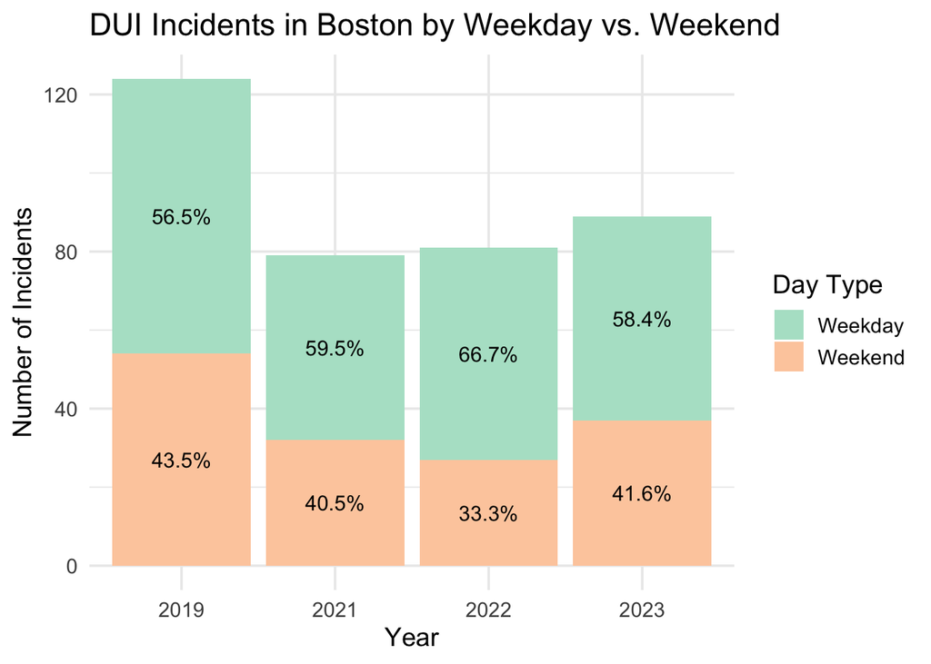

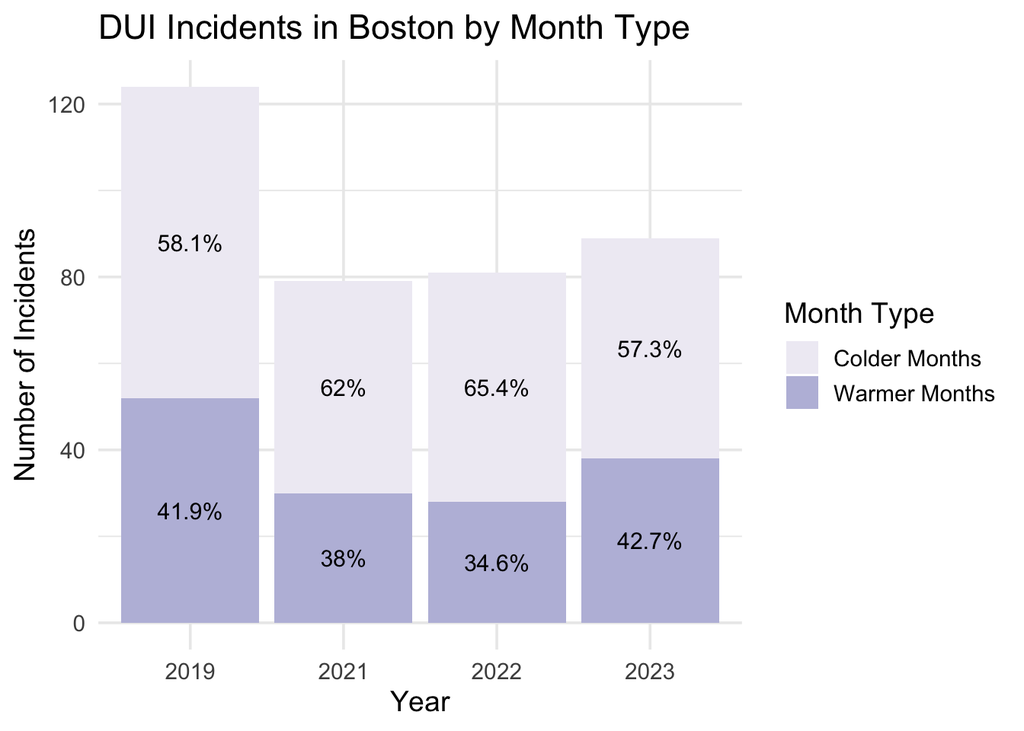

## Conclusions

While the initial hypothesis suggested a higher proportion of DUI incidents in Boston during holidays, weekends, and warmer months, the analysis of four years of data did not support this assumption. The results indicate that the majority of DUI incidents occurred outside of the holidays with more incidents on weekdays than weekends, and more incidents during the colder months than warmer months.

These findings highlight the importance of considering data scope and limitations. Since there are only four years of data, broader trends cannot be conclusively determined. Extending the analysis to include data from the past 10-15 years and incorporating additional factors like time of day could provide a more comprehensive understanding of DUI patterns in Boston.